# Data 607-Assignment 1

#### *Rathish Parayil Sasidharan*

## Overview

A Handful Of Cities Are Driving 2016’s Rise In Murders -  
This article is about rise in murder rate across some of the major cities during the period 2014-2016. Also it states that ,in 2016 the rise is more concentrated in a few major cities.  
We are using 2 data sets for comparison , the 2015 data set provides information about 2014 and 2015 murders across major cities. Second data set provides murder information about 2015 and 2016 murders. This is a preliminary data set.  
Following operations are performed as part of this assignment .

1. Read data from external url
2. Rename few columns
3. Summarize the data
4. Subset data by columns and rows
5. Apply data transformation , add new column by deriving value from existing column
6. Join 2 data frame by primary columns
7. Plot BAR chart /Grouped BAR chart for data comparison

Please find the link to the article.

[A Handful Of Cities Are Driving 2016’s Rise In Murders](https://fivethirtyeight.com/features/a-handful-of-cities-are-driving-2016s-rise-in-murders/)

## Prerequisites

Load required packages

```r
library(ggplot2)
library(dplyr)
library(tidyr)
library(curl)
```

### Loading data frame

Read the 2 data CSV file into data frames

```r
#Read the data from git

murder2016 <- read.csv(curl("https://raw.githubusercontent.com/fivethirtyeight/data/master/murder_2016/murder_2016_prelim.csv"))
murder2015 <- read.csv(curl("https://raw.githubusercontent.com/fivethirtyeight/data/master/murder_2016/murder_2015_final.csv"))
```

## Rename the column header

```r
colnames(murder2015)[3] <- 'murders_2014'
colnames(murder2015)[4] <- 'murders_2015'

colnames(murder2016)[3] <- 'murders_2015'
colnames(murder2016)[4] <- 'murders_2016'
```

## Display the summary data

```r
summary(murder2016)
```

```
##      city              state            murders_2015     murders_2016
##  Length:79          Length:79          Min.   :  0.00   Min.   :  1.00
##  Class :character   Class :character   1st Qu.: 13.00   1st Qu.: 14.50
##  Mode  :character   Mode  :character   Median : 30.00   Median : 30.00
##                                        Mean   : 56.47   Mean   : 62.38
##                                        3rd Qu.: 71.50   3rd Qu.: 81.50
##                                        Max.   :378.00   Max.   :536.00
##      change           source             as_of
##  Min.   :-21.000   Length:79          Length:79
##  1st Qu.: -3.000   Class :character   Class :character
##  Median :  2.000   Mode  :character   Mode  :character
##  Mean   :  5.911
##  3rd Qu.:  9.000
##  Max.   :158.000
```

```r
summary(murder2015)
```

```
##      city              state            murders_2014     murders_2015
##  Length:83          Length:83          Min.   :  0.00   Min.   :  1.00
##  Class :character   Class :character   1st Qu.: 19.50   1st Qu.: 22.50
##  Mode  :character   Mode  :character   Median : 32.00   Median : 39.00
##                                        Mean   : 65.75   Mean   : 75.48
##                                        3rd Qu.: 82.00   3rd Qu.: 94.00
##                                        Max.   :411.00   Max.   :478.00
##      change
##  Min.   :-19.000
##  1st Qu.: -3.000
##  Median :  4.000
##  Mean   :  9.735
##  3rd Qu.: 14.000
##  Max.   :133.000
```

```r
mean_2014murder <- mean(murder2015$murders_2014)
mean_2015murder <- mean(murder2015$murders_2015)
mean_2016murder <- mean(murder2016$murders_2016)

print(paste("Mean of 2014 murders   ",mean_2014murder))
```

```
## [1] "Mean of 2014 murders    65.7469879518072"
```

```r
print(paste("Mean of 2015 murders  ",mean_2015murder))
```

```
## [1] "Mean of 2015 murders   75.4819277108434"
```

```r
print(paste("Mean of 2016 murders  ",mean_2016murder))
```

```
## [1] "Mean of 2016 murders   62.379746835443"
```

## Subset the data by columns and rows

```r
# in this example we are focusing only  cities where murder rates are increased drastically
#find the 10th highest value
top10value2016 =sort(murder2016$change,TRUE)[10];
top10value2015 =sort(murder2015$change,TRUE)[10];

#consider cities which has greater than top 10th crime increase also subset the columns
murder2016_top10 <-subset(murder2016,change >= top10value2016,select = c(city,state,murders_2015,murders_2016,change))

murder2015_top10 <-subset(murder2015,change >= top10value2015)
```

## Data transformation -Add a new column by deriving value from existing column

Add a new columns for increase rate

```r
#add a new column by deriving value from an existing column
murder2016_top10  <- transform(murder2016_top10 ,increase = round(change/murders_2015 *100,0))
murder2015_top10  <- transform(murder2015_top10 ,increase = round(change/murders_2014 *100,0))
```

## Join 2 dataframe

Create a new data from by combining 2 different data frame , which will make the comparison easier. Data frame are joined using city and state.

```r
murder2016_subset  <- transform(murder2016 ,increase_rate = round(change/murders_2015 *100,0))
murder2015_subset  <- transform(murder2015 ,increase_rate = round(change/murders_2014 *100,0))

murder2016_subset <-subset(murder2016_subset,select = c(city,state,increase_rate,change))
murder2015_subset <-subset(murder2015_subset,select = c(city,state,increase_rate,change))

joinedresult = inner_join(murder2016_subset , murder2015_subset, by = c("city","state"), suffix = c("_2016","_2015"))
joinedresult10 <- head(joinedresult,10)
```

## Bar plot

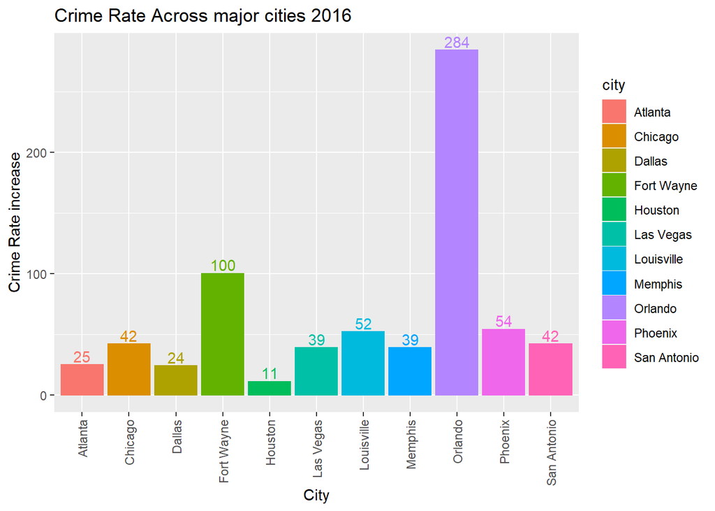

```r
ggplot(data=murder2016_top10, aes(x=city, y=increase,color=city,fill=city)) +  geom_bar(stat="identity") +labs(title='Crime Rate Across major cities 2016',x='City',y='Crime Rate increase') + theme(axis.text.x = element_text(angle = 90, vjust = 0.5, hjust=1))+geom_text(aes(label=increase), position=position_dodge(width=0.9), vjust=-0.25)
```

## Grouped Bar Plot

Comparison of murder rate in 2015 and 2016

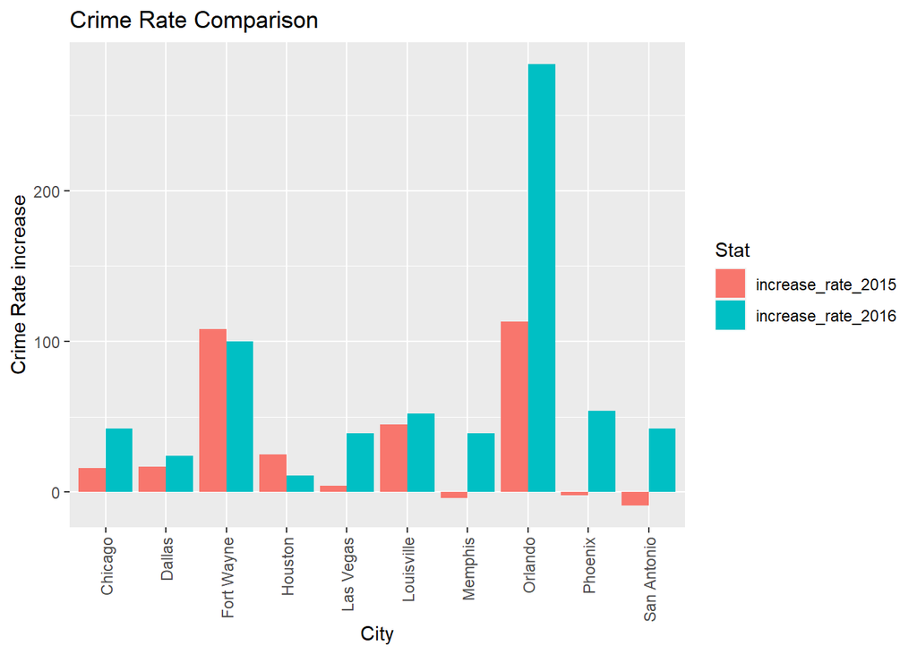

```r
joinedresult10_new <-subset(joinedresult10,select = c(city,increase_rate_2016,increase_rate_2015))

joinedresult10_new_transform <- joinedresult10_new %>%
  gather("Stat", "Value", -city)


ggplot(joinedresult10_new_transform, aes(x = city, y = Value, fill = Stat)) +
 geom_col(position = "dodge")+labs(title='Crime Rate Comparison',x='City',y='Crime Rate increase')+ theme(axis.text.x = element_text(angle = 90, vjust = 0.5, hjust=1))
```

## Conclusions

From the data analysis it is clear that there is widespread rise in murder rate in 2015. In 2016 it appears more concentrated in few big cities like Chicago and Orlando.